# Carbon sequestration and biodiversity co‐benefits of preserving forests in the western United States - Buotte - 2020 - Ecological Applications - Wiley Online Library

[Ecological Applications](https://esajournals.onlinelibrary.wiley.com/journal/19395582)

[Volume 30, Issue 2](https://esajournals.onlinelibrary.wiley.com/toc/19395582/2020/30/2) ee02039

[figure not shown]

Article

Open Access

# Carbon sequestration and biodiversity co‐benefits of preserving forests in the western United States

[Polly C. Buotte](https://esajournals.onlinelibrary.wiley.com/action/doSearch?ContribAuthorStored=Buotte%2C+Polly+C)

E‐mail:

[Beverly E. Law](https://esajournals.onlinelibrary.wiley.com/action/doSearch?ContribAuthorStored=Law%2C+Beverly+E)

[William J. Ripple](https://esajournals.onlinelibrary.wiley.com/action/doSearch?ContribAuthorStored=Ripple%2C+William+J)

[Logan T. Berner](https://esajournals.onlinelibrary.wiley.com/action/doSearch?ContribAuthorStored=Berner%2C+Logan+T)

First published: 04 December 2019

https://doi.org/10.1002/eap.2039

Citations: 5

Corresponding Editor: Yude Pan.

## Abstract

Forest carbon sequestration via forest preservation can be a viable climate change mitigation strategy. Here, we identify forests in the western conterminous United States with high potential carbon sequestration and low vulnerability to future drought and fire, as simulated using the Community Land Model and two high carbon emission scenario (RCP 8.5) climate models. High‐productivity, low‐vulnerability forests have the potential to sequester up to 5,450 Tg CO<sub>2</sub> equivalent (1,485 Tg C) by 2099, which is up to 20% of the global mitigation potential previously identified for all temperate and boreal forests, or up to ~6 yr of current regional fossil fuel emissions. Additionally, these forests currently have high above‐ and belowground carbon density, high tree species richness, and a high proportion of critical habitat for endangered vertebrate species, indicating a strong potential to support biodiversity into the future and promote ecosystem resilience to climate change. We stress that some forest lands have low carbon sequestration potential but high biodiversity, underscoring the need to consider multiple criteria when designing a land preservation portfolio. Our work demonstrates how process models and ecological criteria can be used to prioritize landscape preservation for mitigating greenhouse gas emissions and preserving biodiversity in a rapidly changing climate.

## Introduction

Since the signing of the United Nations Framework Convention on Climate Change in Rio de Janeiro in 1992, the United Nations has recognized the need to formulate a global response to increasing greenhouse gas concentrations in our atmosphere. The subsequent adoptions of the Sustainable Development Goals (United Nations General Assembly 2015) and the Paris Agreement (United Nations Framework Convention on Climate Change (UNFCC) 2015) provided global targets for preserving biodiversity and limiting the negative effects of increasing greenhouse gas concentrations. Limiting global temperature to 1.5°C above the preindustrial average would limit negative climate impacts (IPCC 2018), including negative effects on biodiversity (Smith et al. 2018). Unfortunately, substantial enhancement or over‐delivery of emissions goals in the Paris Agreement is necessary to limit warming to less than 2°C (Rogelj et al. 2016). Missing this target could destabilize Earth's climate, terrestrial, and aquatic systems (Steffen et al. 2018) with catastrophic consequences for biodiversity (Davis et al. 2018), ecosystem services, and humans (Barnosky et al. 2012). Already, ample observational evidence exists that changes in climate are inducing ecosystem transformations through tree mortality (Allen et al. 2010, Millar and Stephenson 2015) and changes in species composition (Allen and Breshears 1998, Millar and Stephenson 2015). Process‐based (Settele et al. 2014, McDowell et al. 2016) and statistical (Rehfeldt et al. 2006, Williams et al. 2007, Pearson et al. 2013) models indicate a strong potential for continued ecological transformation, and paleological analyses indicate that, if we continue on our current emission trajectory, drastic changes in global ecosystem structure and function are likely by the end of this century (Nolan et al. 2018a).

Along with emissions, multiple biogeophysical processes, including carbon uptake by the land and oceans and ocean heat exchange (Solomon et al. 2009), influence atmospheric CO<sub>2</sub> (Canadell et al. 2007, Le Quere et al. 2018) and the integrated Earth system trajectory (Barnosky et al. 2012, Steffen et al. 2018). Recent measurements indicate the ocean heat uptake is at the high end of previous estimates (Resplandy et al. 2018), and decreasing land carbon uptake relative to carbon emissions (Canadell et al. 2007) is contributing to increasing atmospheric CO<sub>2</sub> and chances of climate destabilization (Barnosky et al. 2012, Steffen et al. 2018). Land preservation and timber harvest management (natural climate solutions) are viable options for avoiding greenhouse gas emissions and increasing the magnitude of the land carbon sink (Griscom et al. 2017).

Forest management (e.g., land preservation, reduced harvest) can contribute to climate change mitigation and the preservation of biodiversity (MEA 2005). Globally, improvements to land management could provide an estimated 37% of the mitigation needed to stabilize warming below 2°C by 2039 (Griscom et al. 2017). Land management can also mitigate the negative effects that climate‐induced ecosystem transformations have on biodiversity and watersheds, which influence ecosystem services that contribute to human well‐being (Canadell and Raupach 2008, Griscom et al. 2017). The effects of land‐use change vary globally (Bright et al. 2017), therefore regional analyses (Cameron et al. 2017, Law et al. 2018) are ideal for prioritizing lands for preservation and improving harvest management.

Here, we simulate potential forest carbon sequestration in the western United States, prioritize forest lands for preservation (i.e., no harvest) based on potential carbon sequestration and vulnerability to drought or fire, and compare this carbon priority ranking with measures of biodiversity to illustrate the spatial synergies and incongruities between these two preservation metrics. We use the Community Land Model 4.5 (CLM) to simulate future forest productivity and vulnerability to drought and fire. We prioritize land based on the spatial convergence of low future vulnerability to natural disturbance and three levels of potential productivity and determine the CO<sub>2</sub> mitigation potential that preserving medium‐ and high‐priority forests could provide. We show the co‐benefits and trade‐offs to biodiversity preservation and ecosystem resilience by comparing current observations of aboveground carbon (Wilson et al. 2013), soil carbon (Weider et al. 2014), and species richness (Jenkins et al. 2015, USGS National Gap Analysis Program 2018) across the three forest carbon preservation priority categories. We use these combined analyses to underscore the need to consider multiple criteria when selecting forest lands for preservation.

## Materials and Methods

### Simulations of future forest vulnerability and potential carbon sequestration

We used the Community Land Model, version 4.5 (CLM; Oleson et al. 2013) to simulate the forest carbon cycle across the western United States (Appendix S1: Fig. S1) at a 4 × 4 km spatial resolution. The CLM is the land surface model within the Community Earth System Model (Hurrell et al. 2013). The CLM has prognostic carbon and nitrogen cycles and calculates multiple biogeochemical and biophysical process, such as photosynthesis, autotrophic and heterotrophic respiration, carbon allocation to plant tissues, decomposition, and surface energy balance. It also has a fire module that predicts area burned under future climate and biomass fuel conditions. Here, we used climate projections, described below, prescribed vegetation type (Appendix S1: Fig. S1), and prescribed soil type to drive the model. We employed several modifications that improved the CLM's simulation of aboveground carbon, net primary productivity, and ecosystem respiration across the western United States (Buotte et al. 2019b). In particular, these include specification of physiological parameters controlling photosynthesis for the dominant species in the major forest types (Appendix S1: Fig. S1) of the western United States (Berner and Law 2016, Law et al. 2018, Buotte et al. 2019b), enhanced drought sensitivity through species‐specific stomatal response to soil moisture and leaf shedding during periods of drought stress (Buotte et al. 2019b), and improved fire simulation by incorporating regional ignition probabilities and fuel load constraints (Buotte et al. 2019b).

The CLM was started from bare ground and run with 1901–1920 climate data and prognostic fire turned off until soil carbon pools reached equilibrium. Improvements to the representation of drought stress and prognostic fire were implemented beginning in 1901. From 1901 to 1978, we forced CLM with CRUNCEP climate data (Mitchell and Jones 2005) statistically downscaled to 4 × 4 km and bias‐corrected to our 1979–2014 climate data. Climate data from 1979 to 2014 were disaggregated from daily to 3‐h intervals at 4 × 4 km resolution (Abatzoglou 2013). Downscaling and disaggregation details are provided in Buotte et al. (2019b). Furthermore, we used prescribed harvest to insure the model represented present‐day stand ages (Pan et al. 2011).

Our future CLM simulations were driven with two future climate projections. We used a Representative Concentration Pathway (RCP) 8.5 carbon dioxide emissions scenario for our future simulations because it best represents our current trajectory (Peters et al. 2013). We chose general circulation models (GCMs) based on data availability, representation of historical climate, and coverage of the range of projected future climate (Buotte et al. 2019b). We selected IPSL‐CM5A‐MR, which projects warm and dry future conditions, and MIROC5, which is close to the multi‐model average for future temperature and precipitation across the western United States (Buotte et al. 2019b). Climate projections for 2015–2099 were downscaled, bias‐corrected to the 1979–2014 climate observation data (Abatzoglou 2013), and disaggregated to a 3‐h timescale. Downscaling and disaggregation details are provided in Buotte et al. (2019b).

The number of years with low annual allocation to stem growth and/or annual net primary productivity of 0 were used to determine forest vulnerability to drought stress (Buotte et al. 2019b). For each decade, we defined low vulnerability in grid cells with 0 yr of NPP = 0 and low allocation to growth, medium vulnerability in grid cells with 1 yr with NPP = 0 and/or 1–3 yr with low allocation to growth, and high vulnerability in grid cells with more than 1 yr with NPP = 0 and/or more than 3 yr with no allocation to growth (Buotte et al. 2019b). Grid cells were ranked with low, medium, or high vulnerability for both IPSL_CM5A‐MR and MIROC5 forced simulations. For every grid cell, we calculated vulnerability to fire based on the increase in simulated area burned in the future compared with the past, weighted by the simulated area burned in the past (Buotte et al. 2019b). Final drought and fire vulnerability rankings included uncertainty due to climate projections by incorporating the drought and fire vulnerability ranking from simulations using each of the two climate projections, such that (1) uncertain, one GCM simulation ranked as low and one simulation ranked as high; (2) low, both GCMs low; (3) med‐low, one low and one medium; (4) medium, both GCMs medium; (5) med‐high, one medium and one high; (6) high, both GCMs high.

Further details on vulnerability calculation and assessment relative to observed mortality are provided in Buotte et al. (2019b).

We determined potential carbon sequestration (Keith et al. 2009a) by running CLM with no prescribed harvest beyond 2014 and summing net ecosystem productivity (NEP) from 2020 to 2099, thereby allowing forest type, soil properties, climate, and CO<sub>2</sub> concentrations to determine productivity. We pooled cumulative NEP across all grid cells and defined three categories of potential carbon sequestration based on the highest one‐third (>1.12 × 10<sup>5</sup> g /m<sup>2</sup>), middle one‐third, and lowest one‐ third (<3.27 × 10<sup>4</sup> g C/m<sup>2</sup>) of the distribution. We then ranked forested areas to identify low, medium, and high carbon preservation priority based on the spatial coincidence of low future vulnerability to drought and fire and potential carbon sequestration (Appendix S1: Fig. S2). Forests with low vulnerability to future drought and fire and the highest potential carbon sequestration were ranked as high priority for preservation as carbon preserves; low vulnerability and medium carbon sequestration potential were ranked as medium priority; all other combinations were ranked as low priority. Hereafter we refer to forest priority for preservation as carbon preserves as “carbon priority.”

### Tree mortality from bark beetles

Tree mortality from bark beetle attack is an important disturbance in western U.S. forests, but not currently incorporated into CLM. We therefore addressed the potential for future beetle mortality by assessing recent historical beetle mortality (Berner et al. 2017b) and existing future projections of climate suitability for beetle outbreaks (Bentz et al. 2010, Buotte et al. 2017) across our three forest carbon priority rankings.

### Above‐ and belowground carbon stocks

We assessed observation‐based estimates of carbon stocks (i.e., not our simulated carbon stocks) across forests in each carbon priority ranking. We used the Regridded Harmonized World Soil Database V1.2 (Weider et al. 2014) for belowground carbon stocks, and a gridded data set of aboveground carbon stocks based on field measurements and remote sensing (Wilson et al. 2013).

### Species richness and critical habitat

We examined several aspects of biodiversity across forests with low, medium, and high carbon preservation priority. We acquired published tree species richness maps for the United States (Jenkins et al. 2015), species habitat maps for terrestrial vertebrates (amphibians, reptiles, birds, and mammals) from the U.S. Geological Survey Gap Analysis Program (USGS National Gap Analysis Program 2018), and species habitat maps identifying critical habitat by the U.S. Fish and Wildlife Service (U.S. Fish and Wildlife Service 2018). Each map was resampled to the 4 × 4 km CLM grid. We computed terrestrial vertebrate species richness by taxa and across taxa for each grid cell. We also identified whether a terrestrial vertebrate species was listed as threatened or endangered (T&E) by the U.S. Fish and Wildlife Service and then reassessed species richness for this subset of species. Last, we summarized these aspects of species richness and critical habitat by forest carbon priority rank.

## Results

### High‐priority forest distribution and contribution to emissions mitigation

The high‐carbon‐priority forests are primarily along the Pacific coast and the Cascade Mountains, with scattered occurrences in the northern Rocky Mountains of Idaho and Montana (Fig. 1). Forests with medium carbon priority are more widely scattered throughout the western United States (Fig. 1).

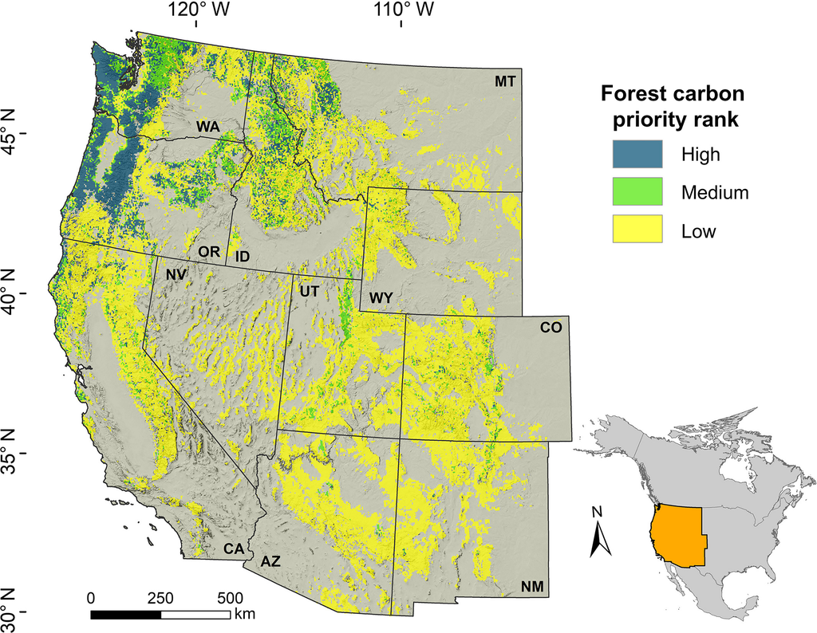

**Figure 1**

Forested land in the western conterminous United States classified into priority for preservation to mitigate climate change based on the spatial co‐occurrence of low vulnerability to drought and fire and low, medium, and high potential carbon sequestration. WA, Washington; ID, Idaho; MT, Montana; OR, Oregon; CA, California; NV, Nevada; UT, Utah; CO, Colorado; AZ, Arizona; NM, New Mexico.

High‐carbon‐priority forests cover 132,016 km<sup>2</sup> or 10.3% of the forested domain and have the potential to sequester 4,815–5,450 Tg CO<sub>2</sub> equivalent (Tg CO<sub>2</sub> e; 1,312–1,485 Tg C) in aboveground carbon between 2020 and 2099 (Fig. 1, Table 1, Appendix S1: Table S1). Medium‐carbon‐priority forests cover 9.5% of the forested domain and could sequester 1,842–2,136 Tg CO<sub>2</sub> e (502–582 Tg C). Low‐carbon‐priority forests cover 80.2% of the forested domain and could sequester 12,789–16,533 Tg CO<sub>2</sub> e (3,485–4,505 Tg C) by 2099. However, because the low‐carbon‐priority forests have higher future vulnerability, their carbon sequestration potential is less certain.

| Priority ranking | Area (km<sup>2</sup>) | Forested domain (%) | Carbon sequestration potential during 2020–2099 (Tg CO<sub>2</sub>e)a | Carbon sequestration potential during 2020–2099 (Tg C/km<sup>2</sup>) |
| --- | --- | --- | --- | --- |
| High | 132,016 | 10.3 | 4,815–5,450 (1,312–1,485 Tg C) | 0.036–0.041 |
| Medium | 120,800 | 9.5 | 1,842–2,136 (502–582 Tg C) | 0.015–0.018 |
| Low | 1,023,872 | 80.2 | 12,789–16,533 (3,485–4,505 Tg C) | 0.012–0.016 |

### Co‐benefits of preserving high‐carbon‐priority forests

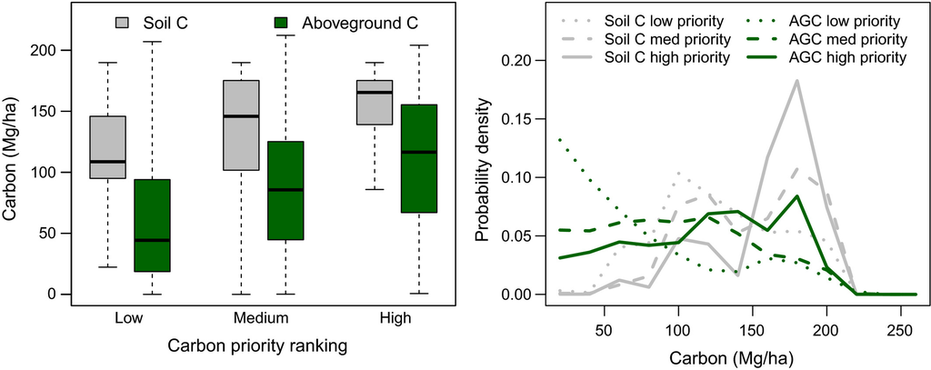

**Figure 2**

Conterminous western U.S. forests ranked with the highest priority for preservation for carbon sequestration also have the highest current soil and aboveground carbon stocks. Carbon stocks from gridded measurements interpolated from observations (see Materials and Methods). Box plot components are mid line, median; box edges, first and third quartiles; and whiskers, max and min.

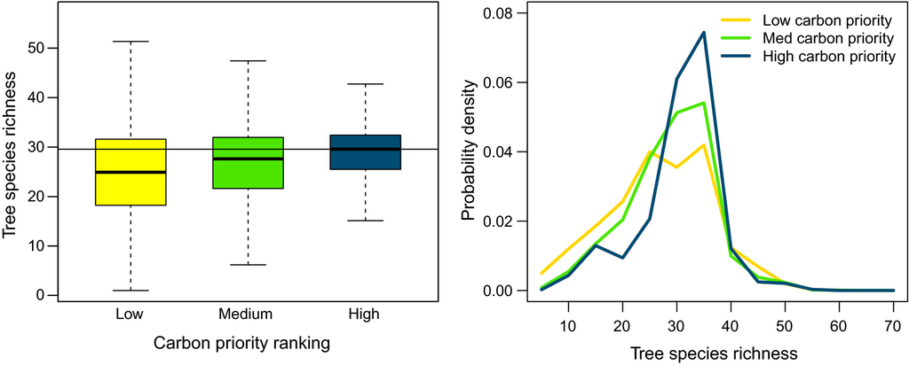

**Figure 3**

Open in figure viewer[PowerPoint](https://esajournals.onlinelibrary.wiley.com/action/downloadFigures?id=eap2039-fig-0003&doi=10.1002%2Feap.2039)

Conterminous western U.S. forests ranked with the highest priority for preservation for carbon sequestration also have the highest present‐day tree species richness (BioDiversityMapping.org richness data).

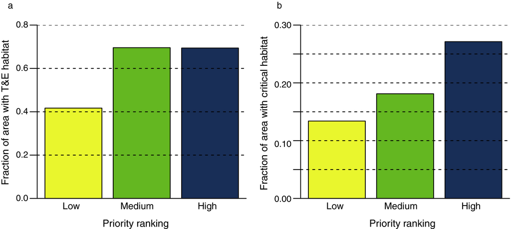

**Figure 4**

## Discussion

Hotter and drier conditions are expected to increase future tree mortality from drought (Allen et al. 2010, McDowell et al. 2016) and fire (Spracklen et al. 2009, Pechony and Shindell 2010) in parts of the western United States, thus preserving forests with the lowest vulnerability to future disturbance is one intuitive component of a land preservation strategy. Forest preservation offers a cost‐effective strategy to avoid and mitigate CO<sub>2</sub> emissions by increasing the magnitude of the terrestrial carbon sink in trees and soil, preserve biodiversity, and sustain additional ecosystem services (Griscom et al. 2017). We show considerable potential for forests in the western United States to sequester additional carbon over the coming century and demonstrate that protecting high‐carbon‐priority areas could help preserve components of biodiversity. However, we also find high biodiversity in some areas with low future carbon sequestration potential due to slow growth or high vulnerability to fire. We therefore suggest that developing area‐based retention targets (Maron et al. 2018) for both carbon and biodiversity metrics, along with the consideration of land ownership (Krankina et al. 2014), would allow the development of a portfolio of preserves to meet these criteria.

We found that high‐carbon‐priority forests in the western United States exhibit features of older, intact forests with high structural diversity (Keith et al. 2009b, Krankina et al. 2014), including carbon density and tree species richness. Forest resilience and adaptive capacity increase with increasing plant species richness (Morin et al. 2018, Watson et al. 2018), suggesting that preserving the high‐carbon‐priority forests would provide an added buffer against potential ecosystem transformation to future climate change.

Intact forests are particularly important for watershed protection by regulating soil permeability, overland flow, and erosion (DellaSala et al. 2011, Creed et al. 2016, Moomaw et al. 2019). Across the United States, National Forests are the largest source of drinking water (Furniss et al. 2010). In the Pacific Northwest, conversion of old‐growth forests to plantations reduced summer stream flow by an average of 50% (Perry and Jones 2017). Preserving intact forests would provide the greatest benefit to watershed protection and clean water supply (DellaSala et al. 2011). Unfortunately, the area of forest interior (defined as forest area per land area) is declining faster than the total area of forest in the United States (Riitters and Wickham 2012). Remaining primary and intact forests need to be identified and incorporated in land management policies.

Indeed, preservation of carbon‐dense primary (Mackey et al. 2015) and intact forests (Watson et al. 2018) is a critical but insufficient criterion for maintaining biodiversity. Secondary forests can support high biodiversity (Donato et al. 2009, Gilroy et al. 2014), as well as different species assemblages compared with primary forests (Ferreira et al. 2018). There are regions identified as globally significant centers of biodiversity (Olson et al. 2012; e.g., the Klamath‐Siskiyou region in southwest Oregon) that we identified with medium to high future vulnerability due to fire. Therefore, when protecting biodiversity is a high conservation priority, disturbance‐prone forests will need to be included in area‐based targets (Maron et al. 2018). Regional assessments (Dass et al. 2018) that simulate vegetation transformation on multi‐decadal timescales are needed to elucidate the effect of future disturbance regimes on plant community composition in order to assess potential future biodiversity and determine preservation priority rankings of disturbance‐prone forests.

Because secondary forests also arise from a legacy of human intervention, conservation of managed landscapes will be an important component of policies to maintain biodiversity and enhance climate mitigation (Kremen and Merenlender 2018). Regional analyses have shown that lengthening harvest cycles can substantially improve carbon sequestration (Law et al. 2018) and biodiversity (Gilroy et al. 2014) and therefore provide pathways for additional climate mitigation (Griscom et al. 2017). Historical stand structure analysis indicates young trees may have played an important role in buffering against particular types of disturbance (Baker and Williams 2015). However, because young trees can be more vulnerable to drought stress than mature trees (Irvine et al. 2002), assessments of future climate vulnerability of young forests will be a critical factor when evaluating harvest strategies (Nolan et al. 2018b). Regional dynamic vegetation simulations with explicit treatment of forest regeneration are necessary to assess the effects of land management scenarios and develop strategies for managed lands.

Assessing the potential for future forest carbon sequestration has inherent uncertainties concerning realized future climate, forest growth, and sources of forest mortality. We address uncertainties in future climate by using two climate scenarios that span a wide range of variability in temperature and precipitation (Buotte et al. 2019b), though we acknowledge that future climate remains uncertain due to the trajectory of carbon emissions, climate sensitivity to these emissions, and climate feedbacks (Collins et al. 2014, Schuur et al. 2015). Furthermore, simulated forest growth depends on how the model was parameterized (White et al. 2000). Here, we used parameterizations developed specifically for forest types in the western United States (Hudiburg et al. 2013, Law et al. 2018, Buotte et al. 2019b), which improved model agreement with historical observations as compared with more general forest type parameterizations (Buotte et al. 2019b). In response to increasing CO<sub>2</sub> concentration, trees may increase their water use efficiency (Keenan et al. 2013, Schimel et al. 2015), however, this response may depend on nutrient availability (Oren et al. 2001, Norby et al. 2010). The CLM incorporates nitrogen limitation (Oleson et al. 2013), which allows the CLM to accurately simulate recent changes in NPP observed under increasing CO<sub>2</sub> concentrations (Smith et al. 2016).

Mountain pine beetles (*Dendroctonus ponderosae*) were responsible for the majority of tree mortality from beetles in the recent past (Meddens et al. 2012). Previous analysis (Buotte et al. 2019b) indicates our drought metric identifies forests vulnerable to beetle attack due to the presence of drought‐stressed trees (Boone et al. 2011), increasing our confidence in our vulnerability metric's ability to capture this important disturbance agent. Importantly, future projections of beetle population dynamics (Bentz et al. 2010) do not indicate increasing beetle populations in areas we define with high carbon priority. Climate suitability for tree mortality from mountain pine beetles is projected to increase in some high‐elevation whitebark pine forests (Buotte et al. 2017), which we ranked with low carbon priority due to lower carbon sequestration potential, or medium to high vulnerability to future drought or fire. Predictive models of beetle population dynamics for multiple beetle species, that include host tree status when appropriate, would increase our ability to incorporate specific spatial representation of future forest vulnerability to beetle attack. We simulated future fire, but the model does not capture the potential for anomalous mega‐fires. Therefore, our estimates of future carbon sequestration potential in the absence of large‐scale mortality events are likely to be robust.

Preservation of high carbon density Pacific Northwest forests that are also economically valuable for timber production will have costs and benefits to consider, including socioenvironmental benefits, the feasibility of preservation, and opportunity costs harvest. There is tremendous potential for proforestation, growing existing forests intact to their ecological potential, which is an effective, immediate, and low‐cost approach to removing carbon dioxide from the atmosphere (Moomaw et al. 2019). Proforestation serves the greatest public good by maximizing co‐benefits such as biological carbon sequestration and unparalleled ecosystem services including biodiversity enhancement, water and air quality, flood and erosion control, and low impact recreation. The development of governance programs to promote forest preservation will be critical. Our study is a first step at identifying areas with the highest potential for natural co‐benefits and proforestation.

## Acknowledgments

This research was supported by the Agriculture and Food Research Initiative of the U.S. Department of Agriculture National Institute of Food and Agriculture (Grants 2013‐67003‐20652, 2014‐67003‐22065, and 2014‐35100‐22066) for our North American Carbon Program studies, “Carbon cycle dynamics within Oregon's urban‐suburban‐forested‐agricultural landscapes” and “Forest die‐off, climate change, and human intervention in western North America,” (and the U.S. Department of Energy (Grant DE‐SC0012194). High‐performance computing resources to run CLM on Cheyenne (https://doi.org/10.5065/d6rx99hx) were provided by NCAR's Computational and Information Systems Laboratory, sponsored by the National Science Foundation.

## Citing Literature

[figure not shown]

[Volume30, Issue2](https://esajournals.onlinelibrary.wiley.com/toc/19395582/2020/30/2)

March 2020

e02039

### Details

  © 2019 The Authors. *Ecological Applications* published by Wiley Periodicals, Inc. on behalf of Ecological Society of America

  This is an open access article under the terms of the [Creative Commons Attribution‐NonCommercial](http://creativecommons.org/licenses/by-nc/4.0/) License, which permits use, distribution and reproduction in any medium, provided the original work is properly cited and is not used for commercial purposes.

[figure not shown]

### Publication History

[Download PDF](https://esajournals.onlinelibrary.wiley.com/doi/pdf/10.1002/eap.2039)

back